# Descriptive Exploration

Author

Timo Roettger

Published

June 6, 2026

# Descriptive exploration

We explore how pitch perception changes as a function of the f0 slope (`delta_f`) and the slope duration (`delta_t`). All analyses will work with the semitone transformed pitch responses.

## Overall means

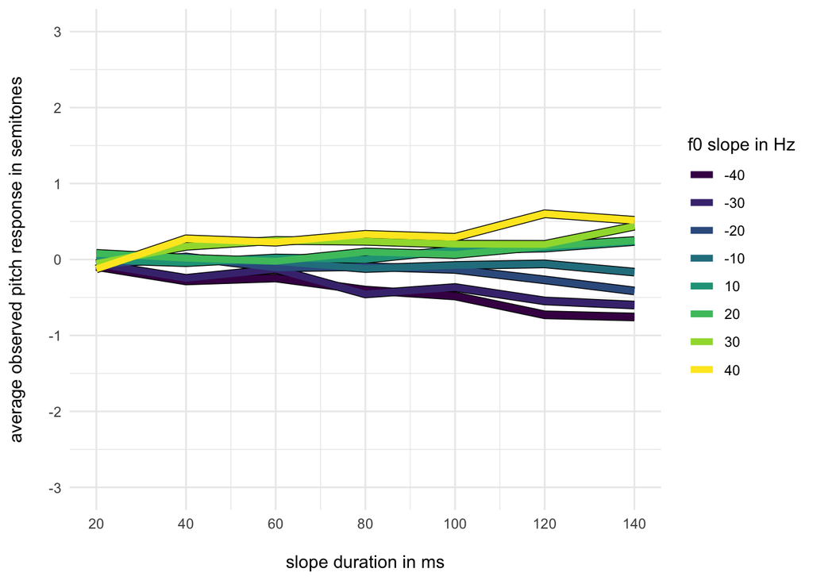

Descriptive means for all combinations of f0 slope in Hz and slope duration in ms

Now we compare these pilot results to the projected results based on Hombert (1975).

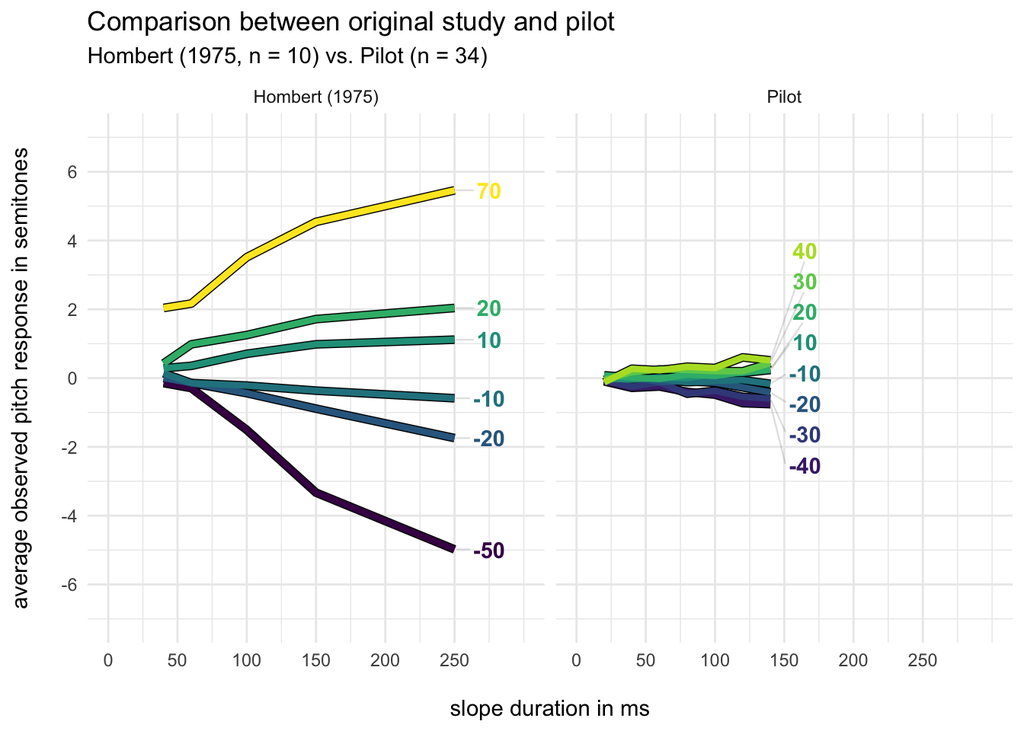

Comparison between descriptive means of Hombert (1975) and our pilot for all combinations of f0 slope and slope duration.

It becomes clear that whatever Hombert (1975) has observed based on 10 American speakers is hardly representative of our pilot results. Looking at only those slope combinations that were used in both Hombert (1975) and our pilot, we can see that the effect magnitudes are substantially smaller:

| Pilot delta_t | f0 perturbation -20 | f0 perturbation -10 | f0 perturbation 10 | f0 perturbation 20 |
| --- | --- | --- | --- | --- |
| 40 | 0.03 | -0.02 | -0.04 | 0.02 |
| 60 | -0.11 | -0.02 | 0.02 | -0.02 |
| 100 | -0.13 | -0.08 | 0.13 | 0.06 |

| Hombert delta_t | f0 perturbation -20 | f0 perturbation -10 | f0 perturbation 10 | f0 perturbation 20 |
| --- | --- | --- | --- | --- |
| 40 | 0.00 | 0.14 | 0.29 | 0.43 |
| 60 | -0.14 | -0.14 | 0.36 | 0.98 |
| 100 | -0.44 | -0.22 | 0.71 | 1.25 |

Project data from Hombert (1975), projected onto reference value of 150Hz, compared to pilot data

## 3-dimensional

Plotting linear prediction of pilot results in three dimensions:

[interactive chart not shown]

## Individual differences

Let’s have a look at individual differences across the pilot data:

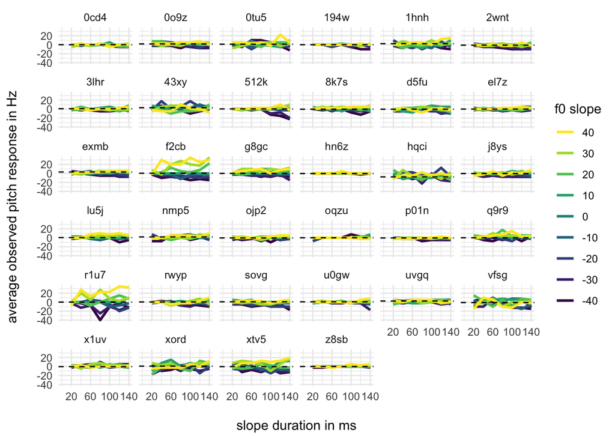

Descriptive means for all combinations of f0 slope in Hz and slope duration in ms across all listeners. Color indicates f0 slope.

The majority of listeners do not seem to show much sensitivity to the manipulation. Two notable exceptions are `f2cb` and `r1u7` who show sensitivity to the directional manipulation of f0 slope.

An alternative perspective can be gained from switching the aesthetic mappings:

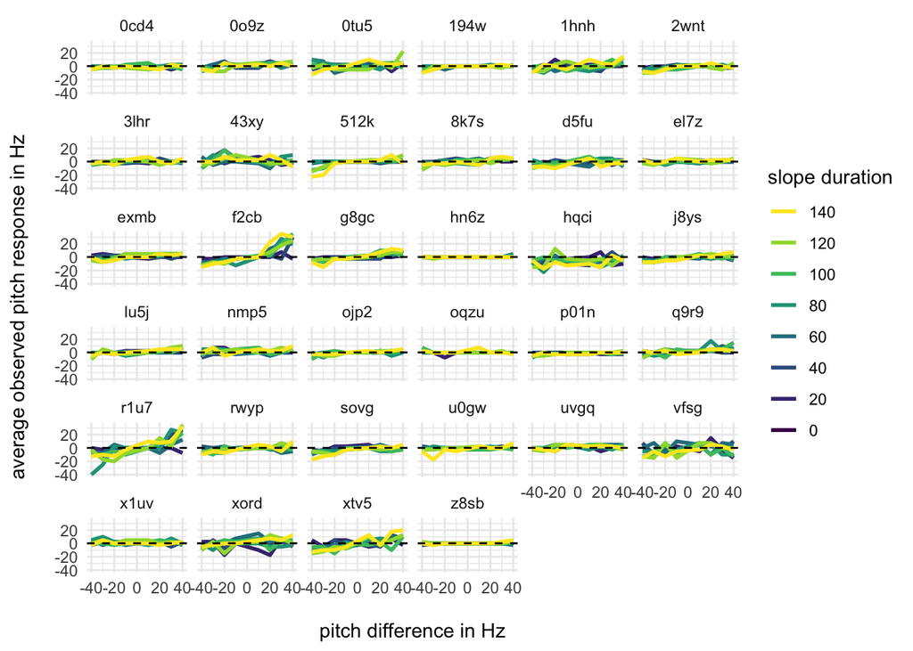

Descriptive means for all combinations of f0 slope in Hz and slope duration in ms across all listeners. Color now indicates slope duration.

To quantify these individual differences, we calculate one metric across all conditions that captures the recovered f0 from the target stimulus. First we explore the proportion of recovered f0 across all f0 perturbations:

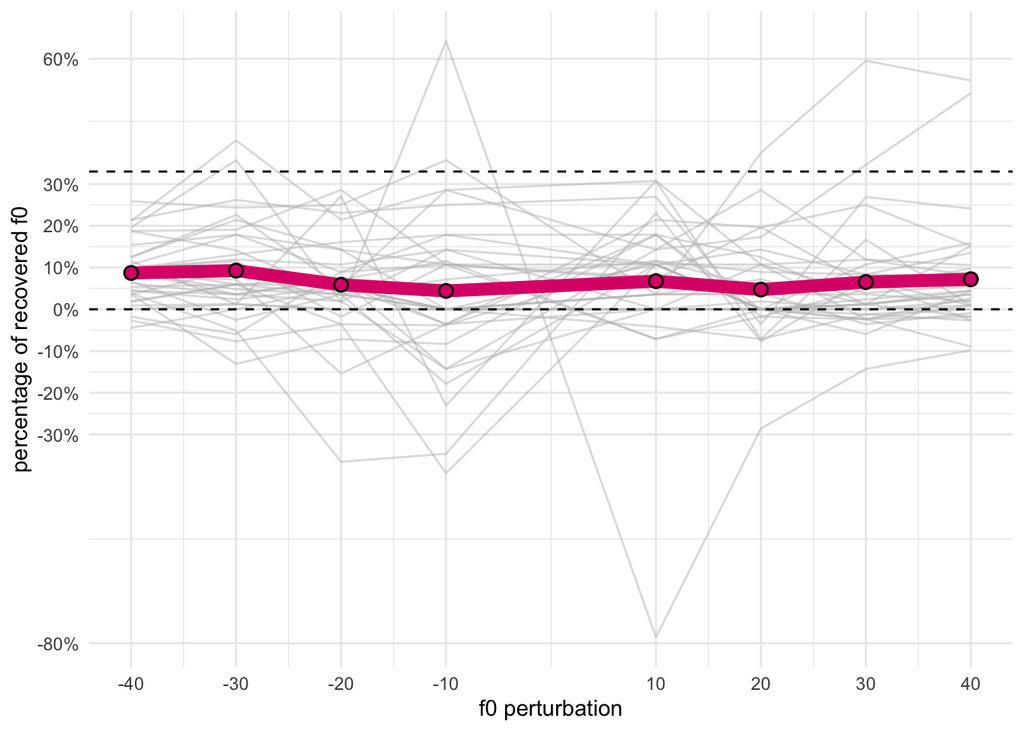

Proportion of recovered f0 across f0 slopes. Grey lines are individual participants; think pink line is population mean. Dashed line at zero indicates null effect; dashed line at 33% indicates predicted ceiling of 1/3 of slope based on Rossi’s work.

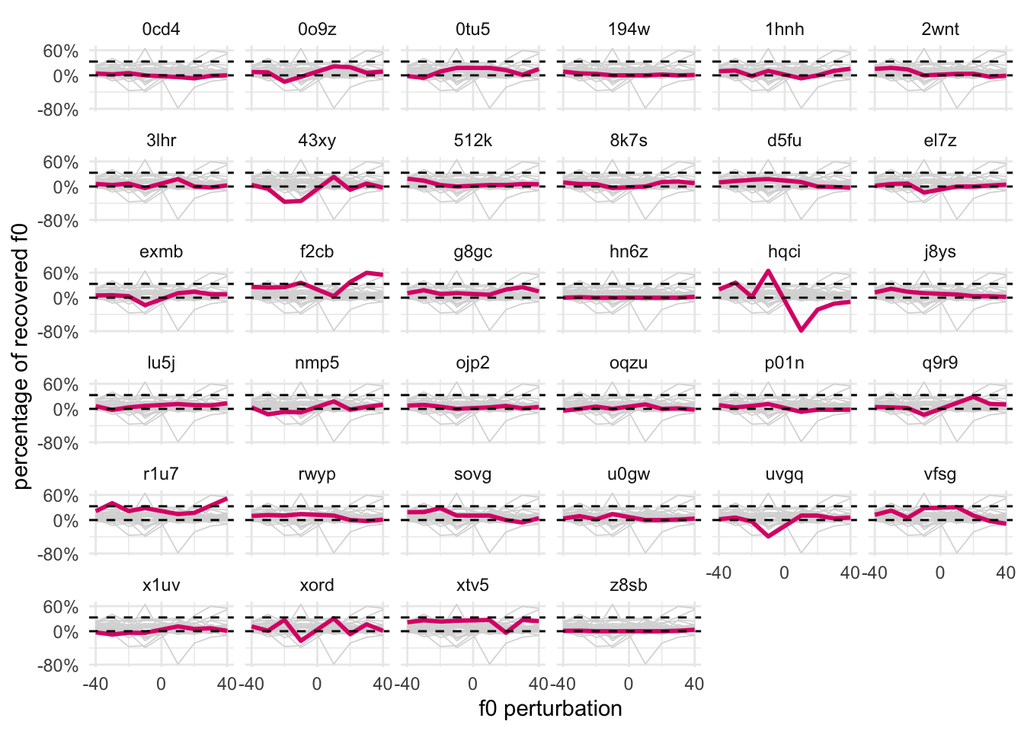

It does not look like as if the amount of f0 perturbation matters for the recovered f0. As opposed to the literature, the average recovered pitch lies between 0 and 10% and not at 1/3 as predicted by Rossi’s work.

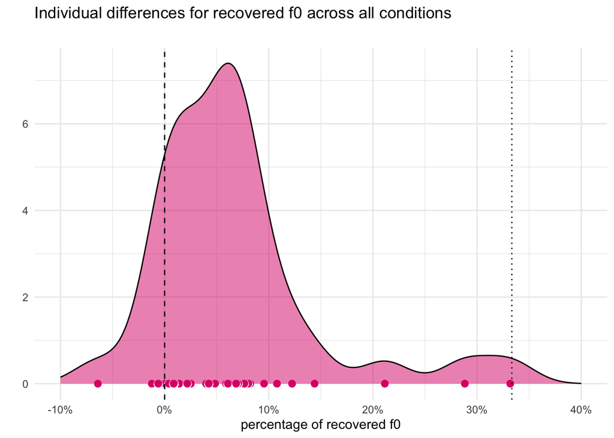

Looking at he distribution of participants’ average recovered f0, we can see a strong mode between 0 and 10% with three outliers that recover f0 above 20%.